# 3次元エビデンス分析ダッシュボード

2026年09月19日 01:28

## 📊 3次元エビデンス分析ダッシュボード

**分析変数**: Dept × Gender × Admit (応答変数: Admit) | **総度数**: N = 4,526 | **最良モデル(BIC)**: M5 | **全体効果量 (Cramér’s V)**: 0.4170 | **run-id**: ucb_jeffreys_0919

#### 🔑 変数定義と因子記号の対応凡例

- A **Dept**
- B **Gender**
- C **Admit**応答変数

※ カテゴリの水準名と、分析上の因子記号（A, B, C）は異なります。以降のモデル構造や数式は本凡例の因子記号に基づきます。

M5

Deptで層別したとき、GenderとAdmitは条件付き独立である (`[AB][AC]`)

候補 9 モデル中 BIC 最小 | ※ 相対的採択であり、真の独立や因果関係を証明するものではありません

明示式BIC: **332.31**

次点 (M8): **ΔBIC +6.89**

🧠 AI エグゼクティブ・サマリー（Pass 2 専門的考察）

# UCB Admissions 3次元対数線形分析 エグゼクティブサマリー

run_id: `ucb_jeffreys_0919`  
主事前: 多項 Jeffreys（各セル α = 0.5）／感度: 単体上一様（α = 1.0）  
結果 SHA-256: `19289826998d061ee62e943d8e1fe662e6801cc0b67be0d28300674f1cd4736a`

## 1. 問いと分母

対象は `examples/ucb_admissions.csv`（UCB Admissions）の集計度数表である。分析変数は Dept（学部）× Gender（性別）× Admit（合否）、度数列は Freq、総度数 *N* = 4, 526、観測セル数は 24（完全セル、観測ゼロなし）。応答変数は Admit とし、条件付き割合は

*P*(Admit = Admitted ∣ Dept, Gender)

を、分母を Admitted と Rejected の和として定義した。比較軸は Gender、基準水準は Female、層別軸は Dept、信用区間水準は点ごとの 95% 等裾区間（ETI）である。本表は志願者構成を固定した記述的分割表であり、因果識別のための無作為化や未観測交絡の不在は仮定していない。

## 2. 構造（M1〜M9）

9階層ポアソン対数線形モデルを、総度数 *N* 基準の明示式 BIC = −2ln *L* + *p*ln *N* で比較した。

- **最良モデル M5**（`[AB][AC]`、Dept で層別したとき Gender と Admit は条件付き独立）: $BIC = 332.3119$、残差自由度 6、逸脱度 21.7355
- **次点 M8**（均一連関 `[AB][AC][BC]`）: $BIC = 339.1982$、自由度 5、逸脱度 20.2043、*Δ*BIC ≈ 6.89
- 相互独立 M1 の BIC は 2324.0717 と大きく劣る

M5 の採択は「候補9モデル内での相対的優位」であり、真の独立や因果関係の証明ではない。全体関連の大きさとして、応答を Admit に畳み込んだ Cramér’s V は 0.417（95%CI の下限側 0.3896）だった。これは大域効果量であり、個々のセルの実務重要度や合否公平性の判定ではない。

## 3. セルと差の大きさ

4軸セル診断を基準モデル別に分離した。

- **M1基準（相互独立）**: 24/24 が REGULAR。Dual-Filter（|log (*O*/*E*)| ≥ 0.50 かつ *T*<sub>*i*</sub><sup>score</sup> ≥ 3.84 かつ REGULAR）の探索候補は **12セル**。例として Dept B・Female・Rejected は log (*O*/*E*) = −2.8987、*T* = 189.44。相互独立仮説からの大きな乖離を示すが、候補件数の合算を「エビデンス率」とは呼ばない。
- **M5基準（条件付き独立）**: REGULAR 13、QUARANTINED 11、探索候補 **1セル**。候補は Dept A・Female・Rejected（*O* = 19、*E* = 38.4309、log (*O*/*E*) = −0.7044、*T* = 17.248、*h* = 0.4304）。対になる Admitted（*O* = 89、*E* = 69.5691、log (*O*/*E*) = 0.2463）は同一 *T* でも |log (*O*/*E*)| < 0.50 のため候補条件を満たさない。

旧 Evidence Score は監査列に隔離し、候補判定には用いていない。leverage は影響度の指標であり、安定性や外れ値そのものではない。現行3次元の候補式に *N* 閾値は入っていない。

## 4. ベイズの不確実性（条件付き割合）

条件付き割合は、対数線形モデルの事後ではなく、**支持集合＝観測表の24行**上の対称 Dirichlet 事後から同時標本化した（構造的ゼロへの疑似度数なし）。新規主解析は各セル α = 0.5（多項 Jeffreys、総事前濃度 *K**α* = 12）、感度は α = 1.0（単体上一様）。旧 α = 1.0 成果物を表示だけ Jeffreys と再ラベルしていない。

代表値（主事前 α = 0.5、20,000 ドロー）:

| 層 | 群 | 度数 | 生割合 | 事後平均 | 95% ETI |
| --- | --- | --- | --- | --- | --- |
| A | Male | 512/825 | 0.6206 | 0.6206 | [0.5876, 0.6529] |
| A | Female | 89/108 | 0.8241 | 0.8209 | [0.7434, 0.8867] |
| F | Male | 22/373 | 0.0590 | 0.0600 | [0.0381, 0.0859] |
| F | Female | 24/341 | 0.0704 | 0.0716 | [0.0467, 0.1007] |

学部 A の男女差（Male − Female）の事後平均は **-0.2004**（95% ETI [−0.2738, −0.1181]）。希少セル例として B・Female（17/25）の事後平均は 0.6724 で、感度 α = 1.0 との差は最大でも事後平均 0.005・中央値 0.0058 程度だった。差の存在をモデル誤りと自動判定しない。分母 d セル中 m セルをまとめた誘導事前は Beta(*m**α*, (*d* − *m*)*α*) であり、セル α = 0.5 を常に $Beta(0.5, 0.5)$ と同一視しない。

## 5. 限界と次の確認

1. BIC 最小の M5 は候補集合内の相対採択であり、データ生成過程の完全特定ではない。
2. M5 基準で 11セルが QUARANTINED（小期待度数または高レバレッジ等）。小規模学部の数値不安定に留意する。
3. 探索候補は多重性未調整の探索的抽出であり、FWER/FDR や実務合否の自動判定ではない。
4. 公平性・差別の判断には志願者属性・得点等の追加交絡と確証的設計が必要で、本結果単独では行わない。
5. 実用上意味のある差の閾値は本設定では未指定。必要なら Pass 0 で合意したうえで再解析する。
6. 追加確認の優先候補: (a) Dept A の Female・Rejected 残余、(b) 希少層 B Female の区間幅、(c) 主事前と感度の差が解釈を変える層の有無。

📈 条件付き割合と事後不確実性（Dirichlet推論）

**注目割合**:

```
P(Admit = Admitted | Dept,
Gender)
```

（分母: Admitted, Rejected の和, 95% 等裾信用区間 ETI）

主事前: symmetric Dirichlet α = 0.5（jeffreys）。支持集合 K = 24。

感度事前 α = 1。事後平均の最大差 = 0.005、中央値の最大差 = 0.0058。差の存在をモデル誤りと自動判定しません。

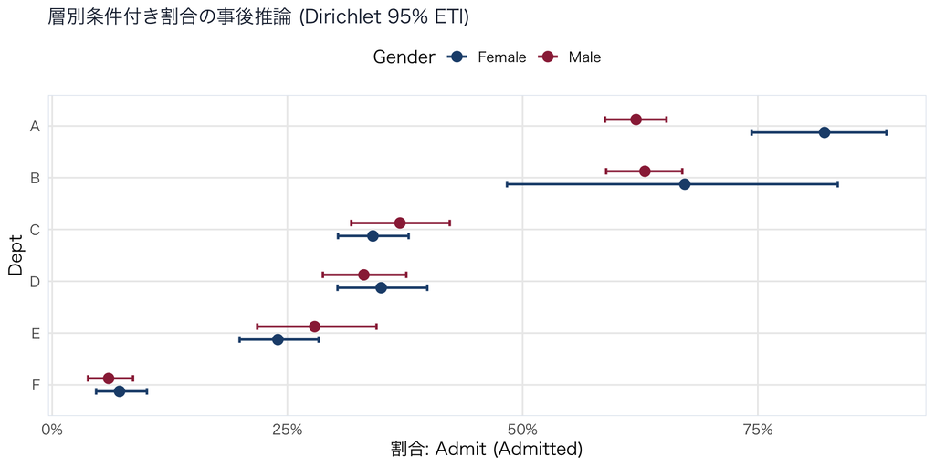

| 層別水準 | 比較水準 | 分子度数 | 分母度数 | 生割合 | 事後平均 | 95%CI下限 | 95%CI上限 |
| --- | --- | --- | --- | --- | --- | --- | --- |
| A | Male | 512 | 825 | 0.6206 | 0.6206 | 0.5876 | 0.6529 |
| A | Female | 89 | 108 | 0.8241 | 0.8209 | 0.7434 | 0.8867 |
| B | Male | 353 | 560 | 0.6304 | 0.63 | 0.5888 | 0.6697 |
| B | Female | 17 | 25 | 0.68 | 0.6724 | 0.4834 | 0.8349 |
| C | Male | 120 | 325 | 0.3692 | 0.3697 | 0.3179 | 0.4226 |
| C | Female | 202 | 593 | 0.3406 | 0.3409 | 0.3038 | 0.3789 |
| D | Male | 138 | 417 | 0.3309 | 0.3313 | 0.2877 | 0.3764 |
| D | Female | 131 | 375 | 0.3493 | 0.3497 | 0.3033 | 0.3987 |
| E | Male | 53 | 191 | 0.2775 | 0.279 | 0.218 | 0.3447 |
| E | Female | 94 | 393 | 0.2392 | 0.2399 | 0.1992 | 0.2832 |

[output cut: 2 more lines]

⚗ 対数線形モデル比較（総度数 N 基準の明示式BIC）

※ *L*: ポアソン完全尤度, *p*: 推定パラメータ数（切片含む）, *N*: 総度数（本解析: 4,526, ln *N* = 8.4176）。**値が小さいほど好ましい**。  
※ **相対評価の原則**: 最良モデルは候補集合における相対的採択であり、真の因果関係を証明するものではありません。

| モデルと仮定 | 生成クラス | 残差自由度 | 逸脱度 | BIC | ΔBIC |
| --- | --- | --- | --- | --- | --- |
| M5: Deptで層別したとき、GenderとAdmitは条件付き独立である 数式・定義 | [AB][AC] | 6 | 21.7355 | 332.3119 | 0 |
| M8: 全2因子交互作用を含み、3因子交互作用を含まない（均一連関） 数式・定義 | [AB][AC][BC] | 5 | 20.2043 | 339.1982 | 6.886300000000006 |
| M9: 飽和モデル（3因子交互作用まで含む） 数式・定義 | [ABC] | 0 | 0 | 361.0819 | 28.77000000000004 |
| M6: Genderで層別したとき、DeptとAdmitは条件付き独立である 数式・定義 | [AB][BC] | 10 | 783.607 | 1060.513 | 728.2011 |
| M2: (Dept, Gender) と Admit は結合独立である 数式・定義 | [AB][C] | 11 | 877.0564 | 1145.5448 | 813.2329 |
| M7: Admitで層別したとき、DeptとGenderは条件付き独立である 数式・定義 | [AC][BC] | 10 | 1148.9009 | 1425.8069 | 1093.495 |
| M3: (Dept, Admit) と Gender は結合独立である 数式・定義 | [AC][B] | 11 | 1242.3503 | 1510.8387 | 1178.5268 |
| M4: (Gender, Admit) と Dept は結合独立である 数式・定義 | [BC][A] | 15 | 2004.2218 | 2239.0398 | 1906.7279 |
| M1: 3因子が相互に独立である 数式・定義 | [A][B][C] | 16 | 2097.6712 | 2324.0717 | 1991.7598 |

#### 🔍 各候補モデルの数理定義・構造仮定詳細

**M1: [A][B][C]**開閉**

##### モデル M1 の数理定義と構造仮定

**生成クラス（ブラケット記法）**: `[A][B][C]` | **実変数展開**: `[Dept][Gender][Admit]`

**独立性仮定**: 3因子が相互に独立である

**適合 formula (R)**: `Freq ~ Dept + Gender + Admit`

残差自由度: 16 | 逸脱度: 2097.67 | BIC: 2324.07 | ΔBIC: 1991.76

**M2: [AB][C]**開閉**

##### モデル M2 の数理定義と構造仮定

**生成クラス（ブラケット記法）**: `[AB][C]` | **実変数展開**: `[Dept, Gender][Admit]`

**独立性仮定**: (Dept, Gender) と Admit は結合独立である

**適合 formula (R)**: `Freq ~ Dept * Gender + Admit`

残差自由度: 11 | 逸脱度: 877.06 | BIC: 1145.54 | ΔBIC: 813.23

**M3: [AC][B]**開閉**

##### モデル M3 の数理定義と構造仮定

**生成クラス（ブラケット記法）**: `[AC][B]` | **実変数展開**: `[Dept, Admit][Gender]`

**独立性仮定**: (Dept, Admit) と Gender は結合独立である

**適合 formula (R)**: `Freq ~ Dept * Admit + Gender`

残差自由度: 11 | 逸脱度: 1242.35 | BIC: 1510.84 | ΔBIC: 1178.53

**M4: [BC][A]**開閉**

##### モデル M4 の数理定義と構造仮定

**生成クラス（ブラケット記法）**: `[BC][A]` | **実変数展開**: `[Gender, Admit][Dept]`

**独立性仮定**: (Gender, Admit) と Dept は結合独立である

**適合 formula (R)**: `Freq ~ Gender * Admit + Dept`

残差自由度: 15 | 逸脱度: 2004.22 | BIC: 2239.04 | ΔBIC: 1906.73

**M5: [AB][AC] 最良モデル (BIC最小)**開閉**

##### モデル M5 の数理定義と構造仮定

**生成クラス（ブラケット記法）**: `[AB][AC]` | **実変数展開**: `[Dept, Gender][Dept, Admit]`

**独立性仮定**: Deptで層別したとき、GenderとAdmitは条件付き独立である

**適合 formula (R)**:

```
 Freq ~ Dept * Gender + Dept *
Admit
```

残差自由度: 6 | 逸脱度: 21.74 | BIC: 332.31 | ΔBIC: 0.00

**M6: [AB][BC]**開閉**

##### モデル M6 の数理定義と構造仮定

**生成クラス（ブラケット記法）**: `[AB][BC]` | **実変数展開**: `[Dept, Gender][Gender, Admit]`

**独立性仮定**: Genderで層別したとき、DeptとAdmitは条件付き独立である

**適合 formula (R)**:

```
 Freq ~ Dept * Gender + Gender
* Admit
```

残差自由度: 10 | 逸脱度: 783.61 | BIC: 1060.51 | ΔBIC: 728.20

**M7: [AC][BC]**開閉**

##### モデル M7 の数理定義と構造仮定

**生成クラス（ブラケット記法）**: `[AC][BC]` | **実変数展開**: `[Dept, Admit][Gender, Admit]`

**独立性仮定**: Admitで層別したとき、DeptとGenderは条件付き独立である

**適合 formula (R)**:

```
 Freq ~ Dept * Admit + Gender *
Admit
```

残差自由度: 10 | 逸脱度: 1148.90 | BIC: 1425.81 | ΔBIC: 1093.50

**M8: [AB][AC][BC]**開閉**

##### モデル M8 の数理定義と構造仮定

**生成クラス（ブラケット記法）**: `[AB][AC][BC]` | **実変数展開**:

```
 [Dept, Gender][Dept,
Admit][Gender, Admit]
```

**独立性仮定**: 全2因子交互作用を含み、3因子交互作用を含まない（均一連関）

**適合 formula (R)**:

```
 Freq ~ Dept * Gender + Dept *
Admit + Gender * Admit
```

残差自由度: 5 | 逸脱度: 20.20 | BIC: 339.20 | ΔBIC: 6.89

**M9: [ABC]**開閉**

##### モデル M9 の数理定義と構造仮定

**生成クラス（ブラケット記法）**: `[ABC]` | **実変数展開**: `[Dept, Gender, Admit]`

**独立性仮定**: 飽和モデル（3因子交互作用まで含む）

**適合 formula (R)**: `Freq ~ Dept * Gender * Admit`

残差自由度: 0 | 逸脱度: 0.00 | BIC: 361.08 | ΔBIC: 28.77

🎯 局所セル診断（基準モデル別残差・4軸診断フレームワーク）

セル診断は基準仮説に応じて異なる問いに答えます。**M1基準**（相互独立からの乖離）と**M5基準**（選択モデルからの残余乖離）をタブで切り替えて確認できます。  
※ 基準モデルごとに前提が異なるため、両者を合算した単一のエビデンス率は定義されません。

#### 「3因子が相互に独立である」という仮説（M1）からの局所的乖離の評価

24 / 24

評価対象セル

24 / 24

安定セル (100.0% REGULAR)

0 / 24

隔離セル (0.0% QUARANTINED)

12 / 24

探索候補セル (50.0%)

N = 4,526

総観測度数

**大標本 Dual-Filter 探索基準**:

```
|log(O/E)| ≥
0.50
```

🏆 効果比 |log(O/E)| 上位 10 セル

| Dept | Gender | Admit | 度数(O) | 期待値(E) | ピアソン残差 | 効果比:log(O/E) | 標準化差 | Score統計量(T) | P値 | 対数P値 | Leverage(h) | 診断状態 |
| --- | --- | --- | --- | --- | --- | --- | --- | --- | --- | --- | --- | --- |
| B | Female | Rejected | 8 | 145.2109 | -11.3865 | -2.8987 | -0.1693 | 189.4383 | 4.216e-43 | -97.57 | 0.3156 | REGULAR |
| A | Female | Rejected | 19 | 231.5928 | -13.9697 | -2.5005 | -0.2076 | 302.8764 | 7.782e-68 | -154.52 | 0.3557 | REGULAR |
| F | Male | Admitted | 22 | 164.6114 | -11.1154 | -2.0125 | -0.1652 | 179.7829 | 5.405e-41 | -92.72 | 0.3128 | REGULAR |
| B | Female | Admitted | 17 | 91.9687 | -7.8174 | -1.6882 | -0.1162 | 78.2571 | 9.046e-19 | -41.55 | 0.2191 | REGULAR |
| F | Female | Admitted | 24 | 112.249 | -8.3295 | -1.5427 | -0.1238 | 90.4264 | 1.92e-21 | -47.7 | 0.2327 | REGULAR |
| B | Male | Admitted | 353 | 134.8707 | 18.7826 | 0.9622 | 0.2792 | 502.4867 | 2.735e-111 | -254.58 | 0.2979 | REGULAR |
| E | Male | Admitted | 53 | 134.6401 | -7.0358 | -0.9323 | -0.1046 | 70.4974 | 4.609e-17 | -37.62 | 0.2978 | REGULAR |
| A | Male | Admitted | 512 | 215.1015 | 20.2435 | 0.8672 | 0.3009 | 619.0289 | 1.216e-136 | -312.96 | 0.338 | REGULAR |
| E | Female | Rejected | 299 | 144.9627 | 12.7937 | 0.724 | 0.1902 | 239.1163 | 6.129e-54 | -122.53 | 0.3155 | REGULAR |
| F | Female | Rejected | 317 | 177.2318 | 10.4987 | 0.5814 | 0.1561 | 164.6238 | 1.105e-37 | -85.1 | 0.3305 | REGULAR |

**📋 全 24 セル 4軸診断テーブル（クリックで展開）**

| Dept | Gender | Admit | 度数(O) | 期待値(E) | ピアソン残差 | 効果比:log(O/E) | 標準化差 | Score統計量(T) | P値 | 対数P値 | Leverage(h) | 診断状態 |
| --- | --- | --- | --- | --- | --- | --- | --- | --- | --- | --- | --- | --- |
| B | Female | Rejected | 8 | 145.2109 | -11.3865 | -2.8987 | -0.1693 | 189.4383 | 4.216e-43 | -97.57 | 0.3156 | REGULAR |
| A | Female | Rejected | 19 | 231.5928 | -13.9697 | -2.5005 | -0.2076 | 302.8764 | 7.782e-68 | -154.52 | 0.3557 | REGULAR |
| F | Male | Admitted | 22 | 164.6114 | -11.1154 | -2.0125 | -0.1652 | 179.7829 | 5.405e-41 | -92.72 | 0.3128 | REGULAR |
| B | Female | Admitted | 17 | 91.9687 | -7.8174 | -1.6882 | -0.1162 | 78.2571 | 9.046e-19 | -41.55 | 0.2191 | REGULAR |
| F | Female | Admitted | 24 | 112.249 | -8.3295 | -1.5427 | -0.1238 | 90.4264 | 1.92e-21 | -47.7 | 0.2327 | REGULAR |
| B | Male | Admitted | 353 | 134.8707 | 18.7826 | 0.9622 | 0.2792 | 502.4867 | 2.735e-111 | -254.58 | 0.2979 | REGULAR |
| E | Male | Admitted | 53 | 134.6401 | -7.0358 | -0.9323 | -0.1046 | 70.4974 | 4.609e-17 | -37.62 | 0.2978 | REGULAR |
| A | Male | Admitted | 512 | 215.1015 | 20.2435 | 0.8672 | 0.3009 | 619.0289 | 1.216e-136 | -312.96 | 0.338 | REGULAR |
| E | Female | Rejected | 299 | 144.9627 | 12.7937 | 0.724 | 0.1902 | 239.1163 | 6.129e-54 | -122.53 | 0.3155 | REGULAR |
| F | Female | Rejected | 317 | 177.2318 | 10.4987 | 0.5814 | 0.1561 | 164.6238 | 1.105e-37 | -85.1 | 0.3305 | REGULAR |

[output cut: 14 more lines]

**📋 旧指標監査（Evidence Score = r² − k·log N）: 正値 19 / 24 セル (79.2%)**

#### 「Deptで層別したとき、GenderとAdmitは条件付き独立である」という仮説（M5）からの局所的乖離の評価

24 / 24

評価対象セル

13 / 24

安定セル (54.2% REGULAR)

11 / 24

隔離セル (45.8% QUARANTINED)

1 / 24

探索候補セル (4.2%)

N = 4,526

総観測度数

**大標本 Dual-Filter 探索基準**:

```
|log(O/E)| ≥
0.50
```

🏆 効果比 |log(O/E)| 上位 10 セル

| Dept | Gender | Admit | 度数(O) | 期待値(E) | ピアソン残差 | 効果比:log(O/E) | 標準化差 | Score統計量(T) | P値 | 対数P値 | Leverage(h) | 診断状態 |
| --- | --- | --- | --- | --- | --- | --- | --- | --- | --- | --- | --- | --- |
| A | Female | Rejected | 19 | 38.4309 | -3.1344 | -0.7044 | -0.0466 | 17.248 | 0 | -10.32 | 0.4304 | REGULAR |
| A | Female | Admitted | 89 | 69.5691 | 2.3296 | 0.2463 | 0.0346 | 17.248 | 0 | -10.32 | 0.6853 | REGULAR |
| B | Female | Rejected | 8 | 9.188 | -0.3919 | -0.1385 | -0.0058 | 0.2537 | 0.6145 | -0.49 | 0.3946 | REGULAR |
| E | Male | Admitted | 53 | 48.0771 | 0.71 | 0.0975 | 0.0106 | 1.0011 | 0.3171 | -1.15 | 0.4964 | REGULAR |
| F | Female | Admitted | 24 | 21.9692 | 0.4333 | 0.0884 | 0.0064 | 0.3841 | 0.5354 | -0.62 | 0.5112 | REGULAR |
| F | Male | Admitted | 22 | 24.0308 | -0.4143 | -0.0883 | -0.0062 | 0.3841 | 0.5354 | -0.62 | 0.5532 | REGULAR |
| B | Female | Admitted | 17 | 15.812 | 0.2988 | 0.0724 | 0.0044 | 0.2537 | 0.6145 | -0.49 | 0.6482 | REGULAR |
| A | Male | Rejected | 313 | 293.5691 | 1.1341 | 0.0641 | 0.0169 | 17.2479 | 0 | -10.32 | 0.9254 | QUARANTINED |
| C | Male | Admitted | 120 | 113.9978 | 0.5622 | 0.0513 | 0.0084 | 0.7535 | 0.3854 | -0.95 | 0.5806 | REGULAR |
| E | Female | Admitted | 94 | 98.9229 | -0.495 | -0.051 | -0.0074 | 1.0011 | 0.3171 | -1.15 | 0.7553 | REGULAR |

**📋 全 24 セル 4軸診断テーブル（クリックで展開）**

| Dept | Gender | Admit | 度数(O) | 期待値(E) | ピアソン残差 | 効果比:log(O/E) | 標準化差 | Score統計量(T) | P値 | 対数P値 | Leverage(h) | 診断状態 |
| --- | --- | --- | --- | --- | --- | --- | --- | --- | --- | --- | --- | --- |
| A | Female | Rejected | 19 | 38.4309 | -3.1344 | -0.7044 | -0.0466 | 17.248 | 0 | -10.32 | 0.4304 | REGULAR |
| A | Female | Admitted | 89 | 69.5691 | 2.3296 | 0.2463 | 0.0346 | 17.248 | 0 | -10.32 | 0.6853 | REGULAR |
| B | Female | Rejected | 8 | 9.188 | -0.3919 | -0.1385 | -0.0058 | 0.2537 | 0.6145 | -0.49 | 0.3946 | REGULAR |
| E | Male | Admitted | 53 | 48.0771 | 0.71 | 0.0975 | 0.0106 | 1.0011 | 0.3171 | -1.15 | 0.4964 | REGULAR |
| F | Female | Admitted | 24 | 21.9692 | 0.4333 | 0.0884 | 0.0064 | 0.3841 | 0.5354 | -0.62 | 0.5112 | REGULAR |
| F | Male | Admitted | 22 | 24.0308 | -0.4143 | -0.0883 | -0.0062 | 0.3841 | 0.5354 | -0.62 | 0.5532 | REGULAR |
| B | Female | Admitted | 17 | 15.812 | 0.2988 | 0.0724 | 0.0044 | 0.2537 | 0.6145 | -0.49 | 0.6482 | REGULAR |
| A | Male | Rejected | 313 | 293.5691 | 1.1341 | 0.0641 | 0.0169 | 17.2479 | 0 | -10.32 | 0.9254 | QUARANTINED |
| C | Male | Admitted | 120 | 113.9978 | 0.5622 | 0.0513 | 0.0084 | 0.7535 | 0.3854 | -0.95 | 0.5806 | REGULAR |
| E | Female | Admitted | 94 | 98.9229 | -0.495 | -0.051 | -0.0074 | 1.0011 | 0.3171 | -1.15 | 0.7553 | REGULAR |

[output cut: 14 more lines]

**📋 旧指標監査（Evidence Score = r² − k·log N）: 正値 1 / 24 セル (4.2%)**

統計用語集・方法論解説・学術リファレンス (Glossary & Scientific References)

統計的・科学的問い:

本ダッシュボードで使用されている3次元対数線形モデル、4軸セル診断、Raoスコア検定、およびベイズDirichlet推論の定義・解釈境界および学術的出典は何か？

**3大利用原則:** ① P値単独判定の排除（全体検定の有意差のみで実務的重要性や個別セルを判定しない） / ② 局所効果（Effect）と統計的証拠（Evidence）の厳格分離（標本数比例の証拠強度と標本数不変の乖離倍率を混同しない） / ③ 不確実性の明示（点推定ではなく等裾信用区間幅で精度を評価）

※ 各項目をクリックして開閉できます。臨床・疫学およびリアルワールドデータ分析におけるエビデンス解釈の拠り所としてご活用ください。

**1. 局所セル診断と 4 軸フレームワーク (Four-Axis Local Cell Diagnostics)**

【第1軸】Effect (局所対数効果比: log(O/E))

基準モデルの期待度数 E に対する観測度数 O の局所対数効果比 λ = log(O/E)。これは倍率そのものではなく倍率の自然対数です。同じ度数構成を c 倍し、同一モデルを再適合した場合に Effect は不変です。

**どこを見るか:** 局所セル診断表（効果比:log(O/E) 列）**誤解しないこと:** 因果効果ではありません。 現行3次元診断は O = 0 かつ E > 0 のとき log(0.5/E) という補正値を格納します。補正値を厳密な log(O/E) として解釈しません。 一般の追加標本や帰無仮説のもとで常に N 比例と断定しません。

【第2軸】Evidence (Leverage補正Score統計量 T_score / 対数P値)

レバレッジ補正スコア z = (O − E) / sqrt(E(1 − h))、T<sub>score</sub> = z<sup>2</sup>。同じ構成比で度数を c 倍し同一モデルを再適合すると、その条件で T<sub>score</sub> は c 倍です。

**どこを見るか:** 局所セル診断表（Score統計量(T) 列、対数P値 列）**誤解しないこと:** 正規／χ<sup>2</sup> 近似には帰無仮説と適切な漸近条件が必要です。h = 1 等の退化では有限な通常式を主張しません。実務的重要性を単独で証明しません。

【第3軸】Influence (レバレッジ h_ii)

一般の3次元モデルではハット行列 H = W<sup>1/2</sup> X (X′WX)<sup>−</sup> X′ W<sup>1/2</sup> の対角成分を用います（基準モデル: M5）。2次元独立モデルの閉形式は流用しません。

**どこを見るか:** 局所セル診断表（Leverage(h) 列）**誤解しないこと:** 高レバレッジは潜在的影響であり、実際の削除影響量そのものではありません。データ異常や外れ値と同一視しません。

【第4軸】Stability (隔離条件 QUARANTINED)

運用上の隔離条件: ① 観測度数 O = 0、② 期待度数 E < 5.0、③ 高レバレッジ h ≥ 0.80 のいずれか。

**どこを見るか:** 局所セル診断表（診断状態 列）**誤解しないこと:** E < 5 や h ≥ 0.80 は運用上の隔離条件であり、近似精度を保証する定理ではありません。第三の臨床群や削除すべき不正データではありません。

大標本 Dual-Filter 原則

探索的候補抽出です。FWER / FDR は保証しません。現行の候補規約: |log(O/E)| ≥ 0.50 かつ T_score ≥ 3.84 かつ REGULAR（現行実装は N 閾値を候補条件に含めない）。

**どこを見るか:** 探索候補セル**誤解しないこと:** 現行3次元の候補式は large_n_threshold を参照しておらず、N > 2000 でのみ計算されると表示しません。この計算差は本表示共通化で変更していません。

**2. 3次元対数線形モデル群と明示式 BIC (Hierarchical Log-Linear Models & Explicit BIC)**

階層的対数線形モデル群 (M1〜M9)

3つの因子 A, B, C の度数データに対して定義される階層構造モデル。M1: [A][B][C] 完全相互独立。M2–M4 は1対2の複合独立、M5–M7 は条件付き独立、M8 は全2因子交互作用、M9 は飽和モデルです。本解析の基準モデルID: M5。

**どこを見るか:** 対数線形モデル比較表（モデルと仮定、生成クラス）**誤解しないこと:** 対数線形モデルは変数間の対称な連関構造をモデル化するものであり、単独で有向な因果関係を主張しません。M1〜M9 / BIC の説明は3次元に限定します。

総度数 N 基準の明示式 BIC

正本はポアソン完全尤度の BIC = −2ℓ̂ + p log N です。K を同じ支持集合のセル数、df = K − p とすると BIC = (G<sup>2</sup> − df log N) + (K log N − 2ℓ<sub>sat</sub>) です。後半は同一データ・支持集合・尤度でモデル共通の定数であり、前半と絶対値は等しくありません。一般の G<sup>2</sup> = 2Σ[O log(O/E) − (O − E)] で、線形項を落とせるのは総適合度数と総観測度数が一致する場合です。

**どこを見るか:** 対数線形モデル比較表（BIC 列、ΔBIC 列）および最良モデル要約帯**誤解しないこと:** 順位・ΔBIC の等価性は同じデータ・支持集合・尤度に限定します。セル数 K ではなく総観測度数 N をペナルティに用いる理由は過剰パラメータ抑制であり、真の独立の証明ではありません。

相対評価の原則 (Principle of Relative Evaluation)

最良モデル（BIC 最小モデル）の採択は、提示された候補モデル集合（M1〜M9）の中での相対的な優位性を示すものです。

**どこを見るか:** 最良モデル表示帯の注記、次点モデルとの ΔBIC**誤解しないこと:** 最良モデルに選定されたことは、真の独立性や因果メカニズムが成立していることを証明しません。

**3. 多項 Dirichlet 事後推論と条件付き確率 (Bayesian Dirichlet & Conditional Inference)**

主事前: 多項Jeffreys（α = 0.5）

Jeffreys 事前の密度は、K−1 個の自由座標で √(det I) に比例します。多項モデルでは Dirichlet(1/2,…,1/2) です。滑らかな一対一再パラメータ化に対する不変性を述べます。本成果物の主事前: 分布族 symmetric_dirichlet、α = 0.5、名称 多項Jeffreys。総事前濃度は Kα = 24 × 0.5 です。α = 0.5 でも影響が無視できるとは限りません。

**どこを見るか:** 条件付き割合セクション（Dirichlet 推論）**誤解しないこと:** 「局所ハール」「過度な平滑化が起きない」とは断定しません。旧成果物のα=1.0を表示だけJeffreysへ変更しません。

感度事前: 単体上一様（Dirichlet(1,…,1)）（α = 1.0）

対照事前 α = 1.0（単体上一様（Dirichlet(1,…,1)））との比較です。 Dirichlet(1,…,1) は単体上で一様であり、各成分の周辺一様を意味しません。

**どこを見るか:** 条件付き割合の感度比較**誤解しないこと:** 事前分布間で推論が変動することは自然な挙動であり、モデル誤りや解析の欠陥と自動判定しません。

等裾信用区間 (Equal-Tailed Interval: 95% ETI)

データ・モデル・事前のもとで定まる事後分位区間です。95% なら対応する両側分位点です。本解析の区間水準: 95%。

**どこを見るか:** 条件付き割合プロットのエラーバー、数値表の区間列**誤解しないこと:** 「真の範囲」や頻度論的被覆の保証とは呼びません。区間幅の狭さは臨床的重要性や有意性そのものではありません。

条件付き割合の事後要約と予測

条件付き割合 q は指定した分子／分母水準のセル確率比です。応答: Admit / 比較: Gender / 層別: Dept / 分子: Admitted / 分母: Admitted, Rejected。次の1観測の予測確率は対応する q の事後平均であり、中央値ではありません。分母 d セル中 m セルをまとめた誘導事前は Beta(mα, (d−m)α) であり、セル α = 0.5 を常に Beta(0.5, 0.5) と同一視しません。

**どこを見るか:** 条件付き割合セクション**誤解しないこと:** 条件付けの方向は因果方向ではありません。同一条件の全カテゴリを含む各ドローとその平均の和は1です（数値誤差・丸めは別）。中央値／分位点の総和は一般には1に制約されませんが、2カテゴリの連続分布では中央値が補数となり和が1となる場合があります。

条件付き割合とシンプソン・パラドックス (Simpson’s Paradox)

周辺集計における見かけの関連が、層別変数で条件付けた場合に消失または逆転する現象です。3次元の選択モデルからのセル診断（log(O/E) 等）とは分けて解釈します。

**どこを見るか:** 条件付き割合プロット**誤解しないこと:** 単一の周辺集計だけで偏りがあると結論づけません。条件付けを因果方向と呼びません。

**4. 学術リファレンス・参考文献 (Scientific References)**

1. Agresti, A. (2013). *Categorical Data Analysis* (3rd ed.). John Wiley & Sons.
2. Haberman, S. J. (1973). The analysis of residuals in cross-classification tables. *Biometrics*, 29(1), 205–220.
3. Haberman, S. J. (1974). *The Analysis of Frequency Data*. University of Chicago Press.
4. Rao, C. R. (1948). Large sample tests of statistical hypotheses concerning several parameters with applications to problems of estimation. *Mathematical Proceedings of the Cambridge Philosophical Society*, 44(1), 50–57.
5. Schwarz, G. (1978). Estimating the dimension of a model. *The Annals of Statistics*, 6(2), 461–464.
6. Pregibon, D. (1981). Logistic regression diagnostics. *The Annals of Statistics*, 9(4), 705–724.
7. Gelman, A., Carlin, J. B., Stern, H. S., Dunson, D. B., Vehtari, A., & Rubin, D. B. (2013). *Bayesian Data Analysis* (3rd ed.). Chapman & Hall/CRC.
8. Okabe, M., & Ito, K. (2008). Color Universal Design (CUD) — How to make figures and presentations that are friendly to Colorblind people.

Generated by **vcd-bayesian-evidence-analysis (4-Axis Multi-Baseline Canonical)** | Rao’s Score Statistic & Explicit BIC (N) | 完全オフライン静的HTML (KaTeX) | 2026-09-19 01:28 JST